# p8105_hw3_yq2279

# Problem 3

- Load, tidy, and otherwise wrangle the data. Your final dataset should include all originally observed variables and values; have useful variable names; include a weekday vs weekend variable; and encode data with reasonable variable classes. Describe the resulting dataset (e.g. what variables exist, how many observations, etc).

```r
df_accel = read_csv("./data/accel_data.csv") %>%
  janitor::clean_names() %>%
  mutate(weekday_or_weekend = case_when(
    day %in% c("Friday", "Monday", "Thursday", "Tuesday", "Wednesday") ~ "weekday",
    day %in% c("Saturday", "Sunday") ~ "weekend",
    TRUE ~ ""
  )) %>%
  select(week, day_id, day,weekday_or_weekend, everything()) %>%
  mutate(
    day = as.factor(day),
    weekday_or_weekend = as.factor(weekday_or_weekend)
    ) %>%
  mutate(day = forcats::fct_relevel(day, c("Monday", "Tuesday", "Wednesday", "Thursday", "Friday", "Saturday", "Sunday"))) %>%
  pivot_longer(
    activity_1:activity_1440,
    names_to = "minite",
    names_prefix = "activity_",
    values_to = "minite_counts"
    ) %>%
  mutate(minite = as.numeric(minite))
```

The variables in this dataset are week, day_id, day, weekday_or_weekend, minite, minite_counts, and there are 50400 observations. The dataset covers 5 weeks which is 35 days.

- Traditional analyses of accelerometer data focus on the total activity over the day. Using your tidied dataset, aggregate accross minutes to create a total activity variable for each day, and create a table showing these totals. Are any trends apparent?

```r
n_activity_day = df_accel %>%
  group_by(week, day) %>%
  summarize(day_counts = sum(minite_counts))

pivot_wider(
  n_activity_day,
  names_from = day,
  values_from = day_counts
  ) %>%
  knitr::kable(digits = 0)
```

| week | Monday | Tuesday | Wednesday | Thursday | Friday | Saturday | Sunday |
| --- | --- | --- | --- | --- | --- | --- | --- |
| 1 | 78828 | 307094 | 340115 | 355924 | 480543 | 376254 | 631105 |
| 2 | 295431 | 423245 | 440962 | 474048 | 568839 | 607175 | 422018 |
| 3 | 685910 | 381507 | 468869 | 371230 | 467420 | 382928 | 467052 |
| 4 | 409450 | 319568 | 434460 | 340291 | 154049 | 1440 | 260617 |
| 5 | 389080 | 367824 | 445366 | 549658 | 620860 | 1440 | 138421 |

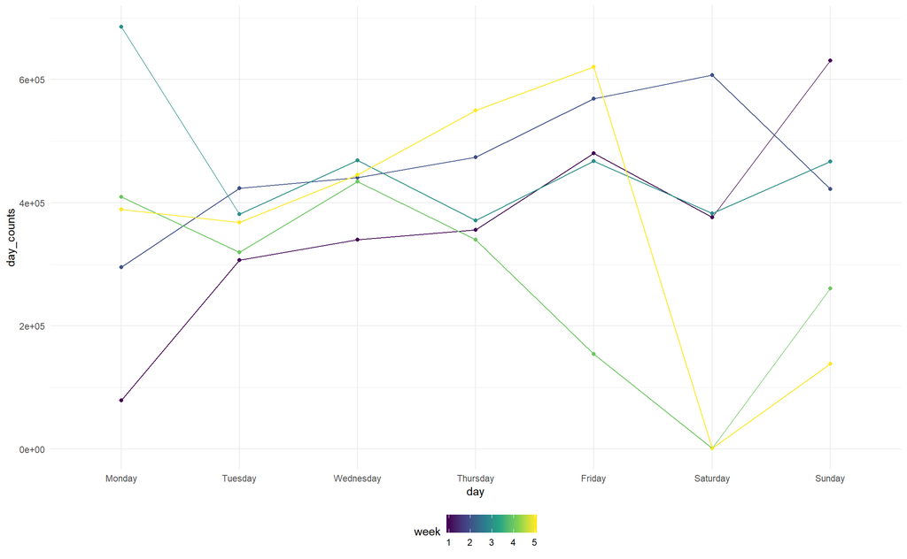

```r
n_activity_day %>%
  ggplot(aes(x = day, y = day_counts, color = week, group = week)) +
  geom_point() +
  geom_line()
```

There is no trend apparent based on the table and plot.

- Accelerometer data allows the inspection activity over the course of the day. Make a single-panel plot that shows the 24-hour activity time courses for each day and use color to indicate day of the week. Describe in words any patterns or conclusions you can make based on this graph.

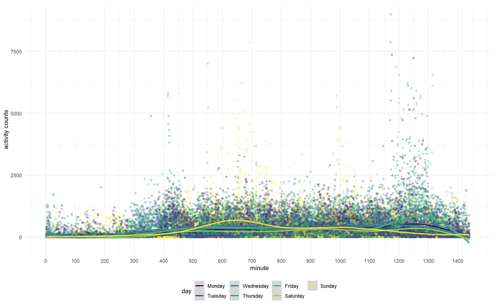

```r
df_accel %>%
  ggplot(aes(x = minite, y = minite_counts, color = day, group = day)) +
  geom_point(alpha = 0.3) +
  geom_smooth(se = TRUE) +
  scale_x_continuous(breaks = seq(0, 1400, by = 100), limits = c(0, 1450), labels = seq(0, 1400, by = 100)) +
  labs(
    x = "minute",
    y = "activity counts"
  )
```

Activity counts are peak when it is around 600 and 1300 minites of the day most days.